# Hierarchical Clustering in R

David Asare Kumi

June 11, 2019

## Hierarchical Clustering

This is for high dimensional data. Clustering organizes things that are close into groups.

### Usefulness

1. Useful for high dimensional data.
2. Organizes the data in a logical and intuitive way.
- How do we define close?
- How do we group things?
- How do we visualize the grouping?
- How do we interpret the grouping?

### Hierarchical Clustering

- Common approach. An agglomerative approach.
1. Find closest two things.
2. Put them together.
3. Find next closest.
- Requires
1. A defined distance.
2. A merging approach.
- Produces
1. A tree showing how close things are to each other.

## Example1

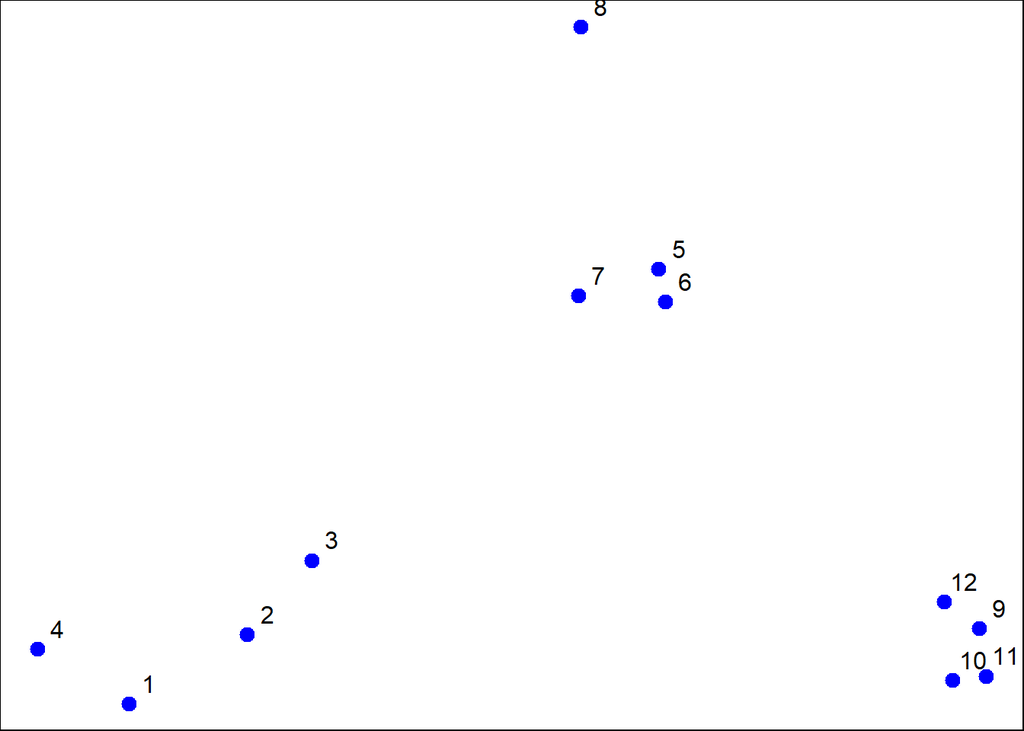

```r
set.seed(1234)
par(mar=c(0,0,0,0))
x <-rnorm(12,mean=rep(1:3,each=4),sd=0.2)
y <-rnorm(12,mean=rep(c(1,2,1),each=4),sd=0.2)
plot(x,y,col="blue",cex=2,pch=20)
text(x+0.05,y+0.05,label=as.character(1:12))
```

## Hierarchical Clustering distance

- The first thing to do is to calculate the distance between all the points.

```r
x <-rnorm(12,mean=rep(1:3,each=4),sd=0.2)
y <-rnorm(12,mean=rep(c(1,2,1),each=4),sd=0.2)
dataFrame <-data.frame(x=x,y=y)
#This calculates the distance between all the different rows and gives you the distance matrix.
dist(dataFrame)
```

```
##             1          2          3          4          5          6
## 2  0.22567641
## 3  0.45453574 0.45554140
## 4  0.34912122 0.19452860 0.32151933
## 5  2.06606082 2.02065407 1.61155503 1.83221127
## 6  1.54900695 1.52555104 1.09601664 1.34492548 0.53624306
## 7  1.85674308 1.86657127 1.41785488 1.69748312 0.51229080 0.40987485
## 8  1.73009597 1.70176589 1.27650523 1.51878993 0.35806878 0.18252696
## 9  2.01088771 2.14887170 1.74877452 2.06554881 1.71988066 1.43636884
## 10 2.05284270 2.19065639 1.78988383 2.10687898 1.73668645 1.46348356
## 11 1.82557596 1.96437831 1.56768589 1.88328671 1.65614908 1.32570361
## 12 1.91424015 2.05619419 1.66259490 1.97746696 1.72181567 1.40860230
##             7          8          9         10         11
## 2
## 3
## 4
## 5
## 6
## 7
## 8  0.33586109
## 9  1.20953025 1.48812335
## 10 1.22768293 1.51123944 0.04195555
## 11 1.14419584 1.39636580 0.18531341 0.22726894
## 12 1.20957637 1.47262776 0.10513031 0.14483002 0.09672377
```

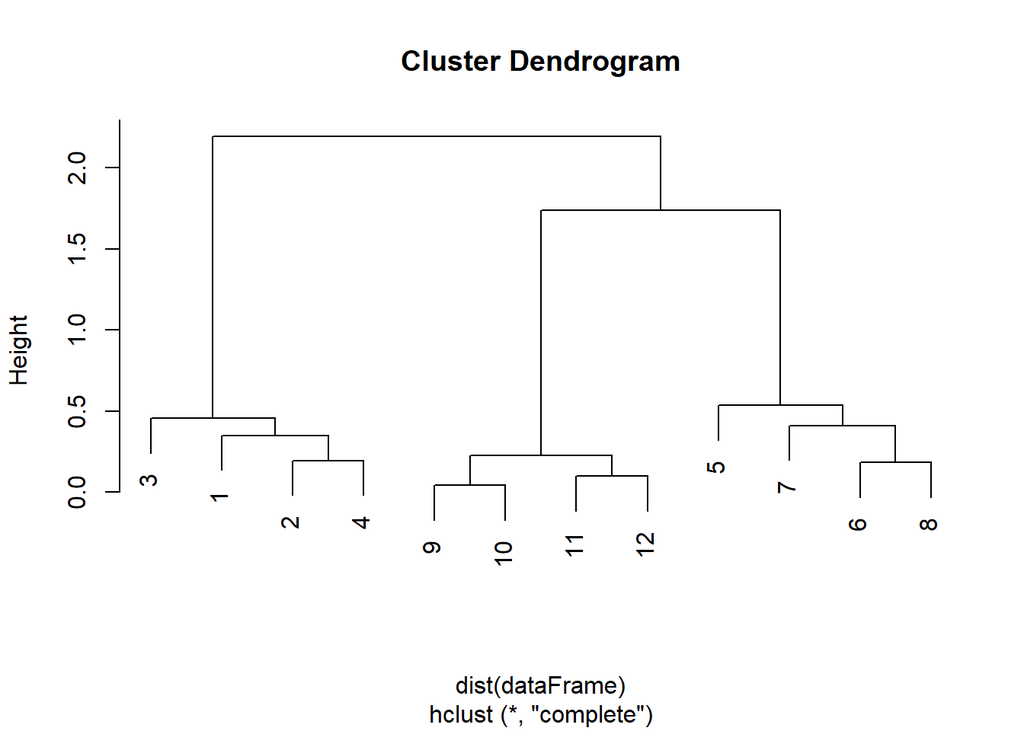

```r
hclustering <-hclust(dist(dataFrame))
plot(hclustering)
```

- The farther down the tree are points merged(clustered) together first and those up the tree are points merged(clustered) later.
- This actually does not tell you how many clusters you have. To resolve this, cut the tree at a certain point to determine how many clusters there are.
- If you cut the tree at 2, you get 2 clusters. If you cut the tree at 1, you get 3 clusters.
- It is important to note that we do not have a rule for cutting the tree.

## heatmap() function

- This runs a hierarchical analysis on the rows and columns of the table.
- Heatmap function is useful for quickly looking at table or matrix data.

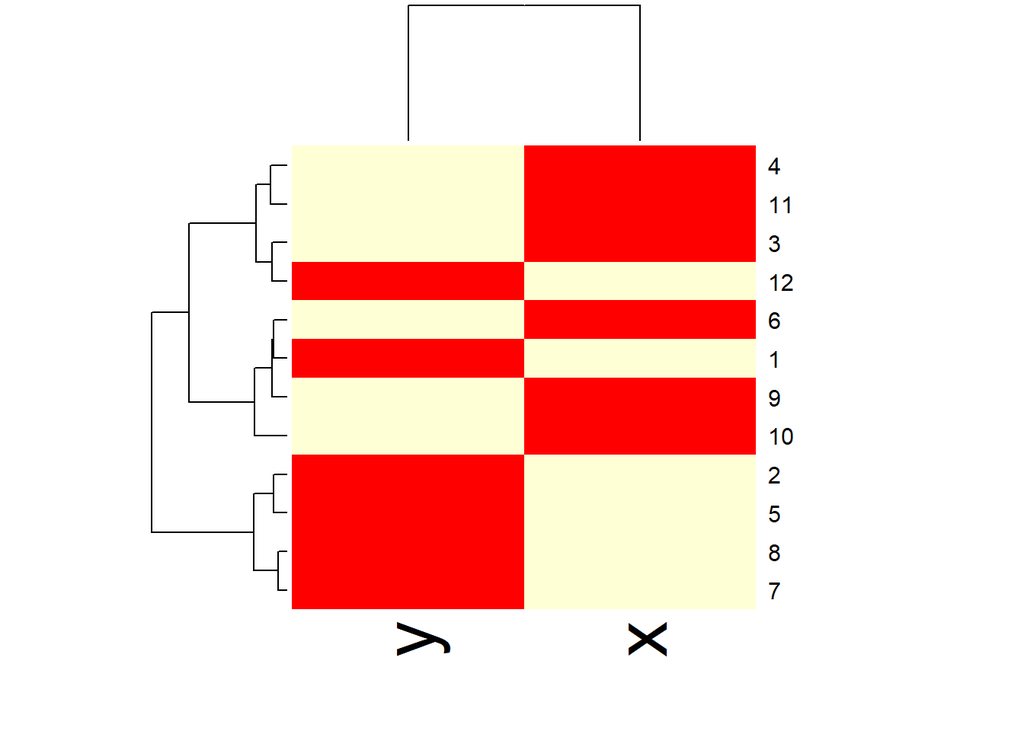

```r
x <-rnorm(12,mean=rep(1:3,each=4),sd=0.2)
y <-rnorm(12,mean=rep(c(1,2,1),each=4),sd=0.2)
dataFrame <-data.frame(x=x,y=y)
set.seed(123)
dataMatrix <-as.matrix(dataFrame)[sample(1:12),]
heatmap(dataMatrix)
```

## K-Means Clustering

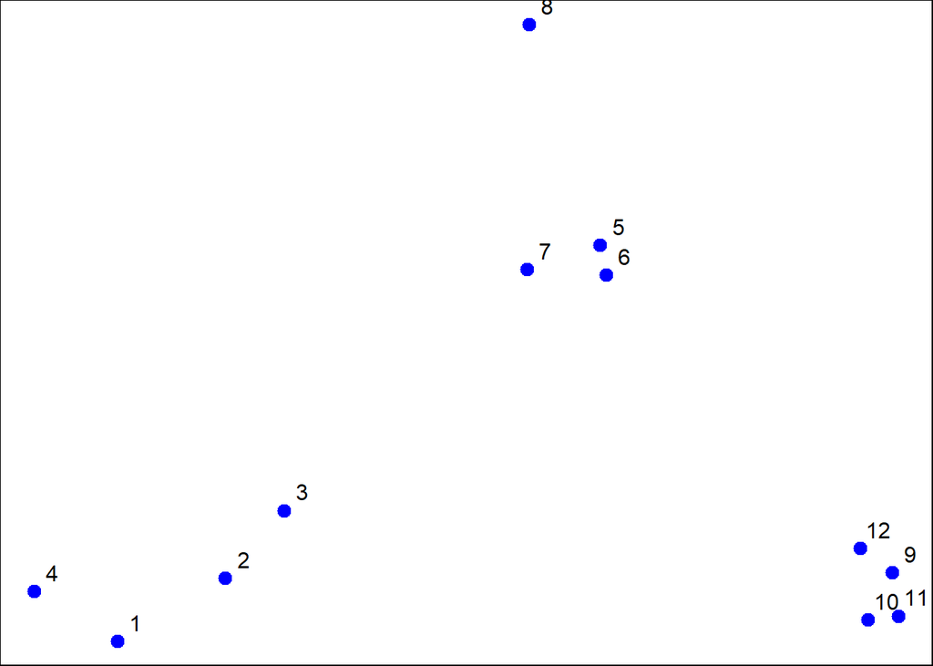

```r
set.seed(1234)
par(mar=c(0,0,0,0))
x <-rnorm(12,mean=rep(1:3,each=4),sd=0.2)
y <-rnorm(12,mean=rep(c(1,2,1),each=4),sd=0.2)
plot(x,y,col="blue",pch=20,cex=2)
text(x+0.05,y+0.05,labels=as.character(1:12))
```

```r
#K-means clustering (part 2)
dataFrame <-data.frame(x,y)
kmeansObj <-kmeans(dataFrame,centers=3)
names(kmeansObj)
```

```
## [1] "cluster"      "centers"      "totss"        "withinss"
## [5] "tot.withinss" "betweenss"    "size"         "iter"
## [9] "ifault"
```

```r
kmeansObj$cluster
```

```
##  [1] 3 3 3 3 1 1 1 1 2 2 2 2
```

```r
kmeansObj$centers #This tells you the location of the centroids in the space
```

```
##           x         y
## 1 1.9906904 2.0078229
## 2 2.8534966 0.9831222
## 3 0.8904553 1.0068707
```

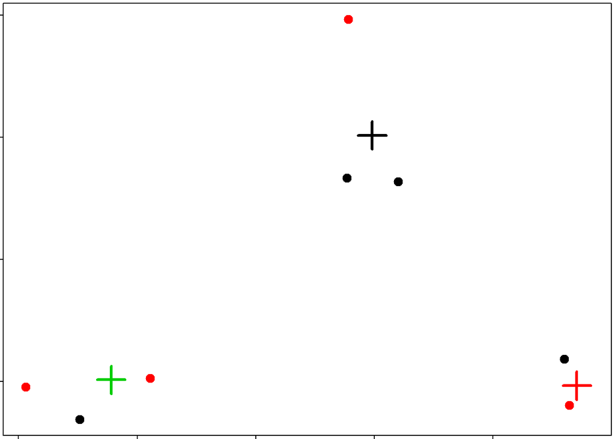

```r
#Plot
par(mar=rep(0.2,4))
plot(x,y,col=kmeansObj$centers,pch=20,cex=2)
points(kmeansObj$centers,col=1:3,pch=3,cex=3,lwd=3)
```

## Heatmaps

We can also use heatmaps here.

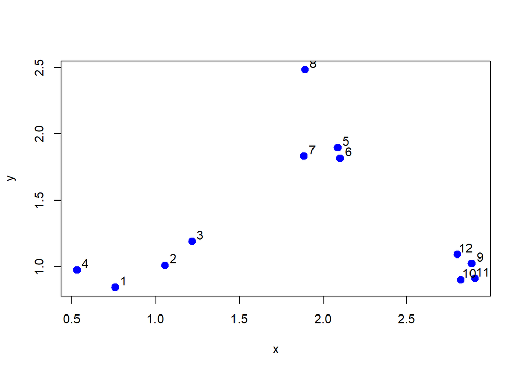

```r
set.seed(1234)
x <-rnorm(12,mean=rep(1:3,each=4),sd=0.2)
y <-rnorm(12,mean=rep(c(1,2,1),each=4),sd=0.2)
plot(x,y,col="blue",pch=20,cex=2)
text(x+0.05,y+0.05,labels=as.character(1:12))
```

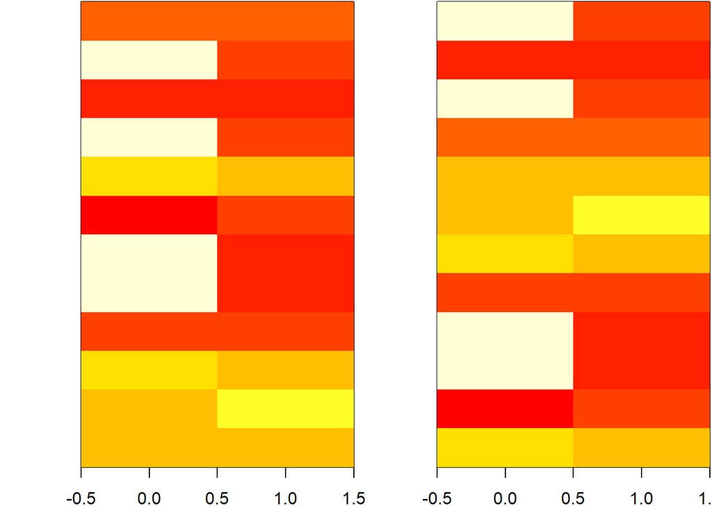

```r
dataFrame <-data.frame(x,y)
dataMatrix <-as.matrix(dataFrame)[sample(1:12),]
kmeansObj2 <-kmeans(dataMatrix,centers=3)
par(mfrow=c(1,2),mar=c(2,4,0.1,0.1))
image(t(dataMatrix)[,nrow(dataMatrix):1],yaxt="n")
image(t(dataMatrix)[,order(kmeansObj$cluster)],yaxt="n")
```

## Dimension Reduction (part1)

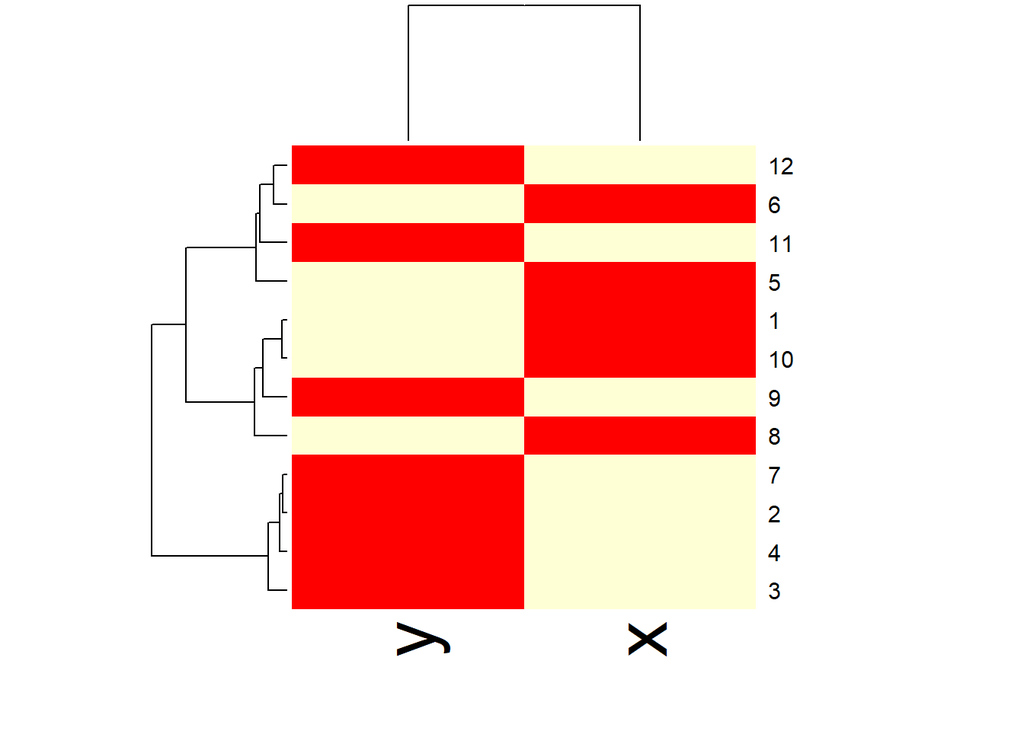

```r
x <-rnorm(12,mean=rep(1:3,each=4),sd=0.2)
y <-rnorm(12,mean=rep(c(1,2,1),each=4),sd=0.2)
dataFrame <-data.frame(x,y)
dataMatrix <-as.matrix(dataFrame)[sample(1:12),]
par(mar=rep(0.2,4))
heatmap(dataMatrix)
```

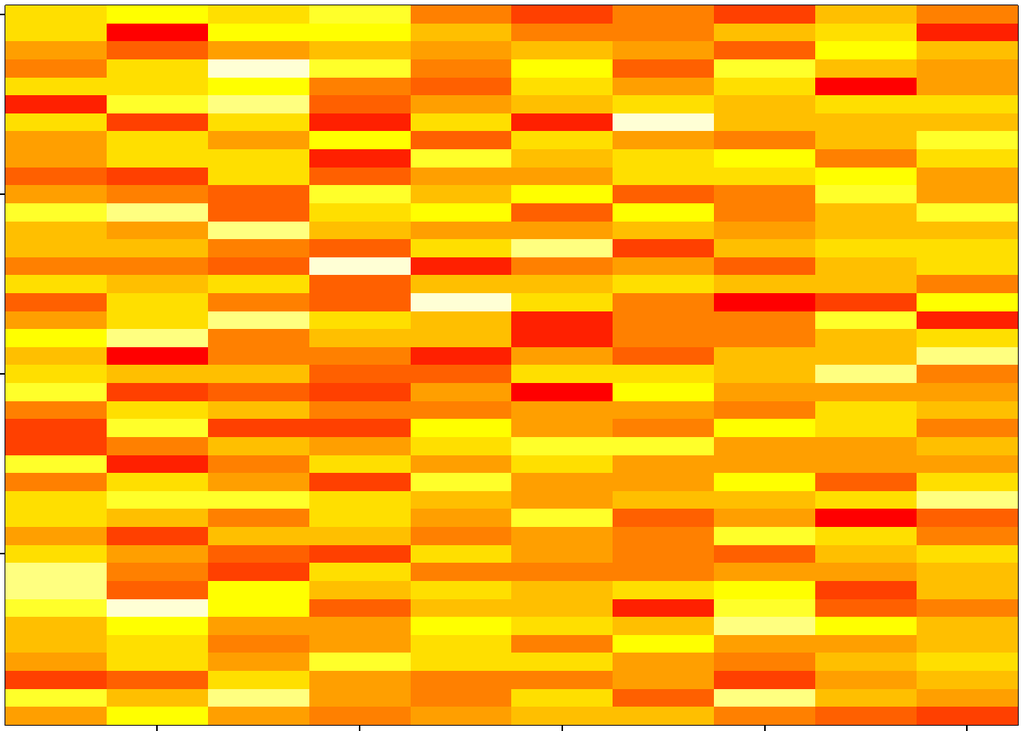

```r
#Matrix data
set.seed(12345)
par(mar=rep(0.2,4))
dataMatrix <-matrix(rnorm(400),nrow=40)
image(1:10,1:40,t(dataMatrix)[,nrow(dataMatrix):1])
```

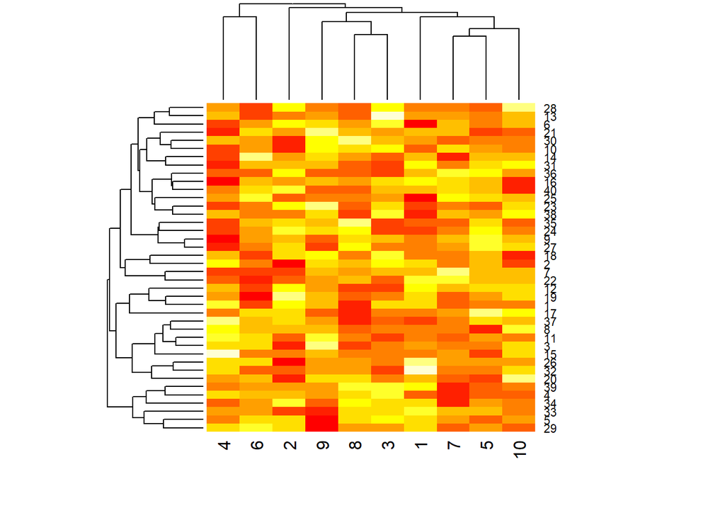

```r
#Run the heatmap function
heatmap(dataMatrix)
```

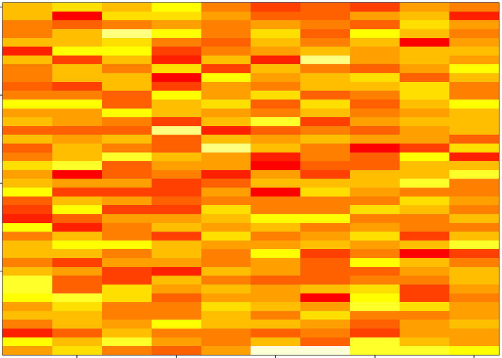

```r
#What if we add a pattern
set.seed(678910)
for(i in 40){
  #flip a coin
  coinFlip <-rbinom(1,size=1,prob=0.5)
  #if coin is heads add a common pattern to the row
  if(coinFlip){
    dataMatrix[i,]<-dataMatrix[i,]+rep(c(0,3),each=5)
  }
}
#plot pattern data
par(mar=rep(0.2,4))
image(1:10,1:40,t(dataMatrix)[,nrow(dataMatrix):1])
```

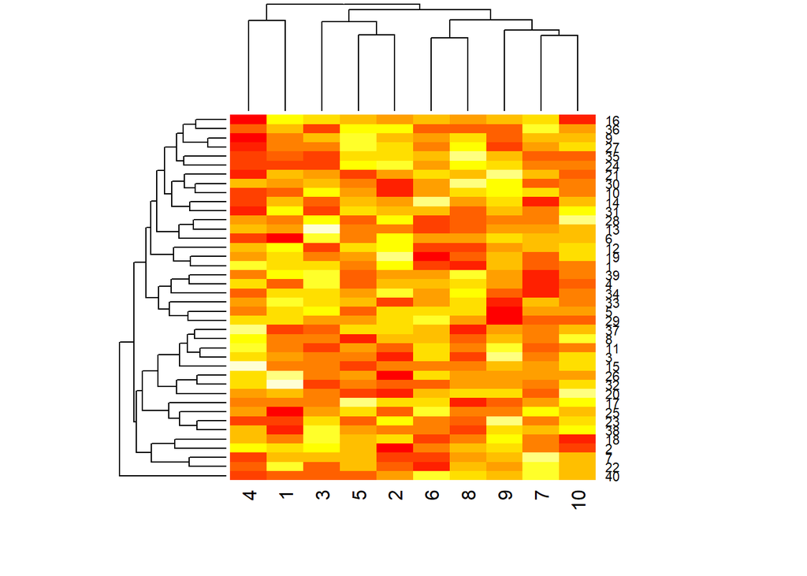

```r
#What if we add a pattern? the clustered data
par(mar=rep(0.2,4))
heatmap(dataMatrix)
```

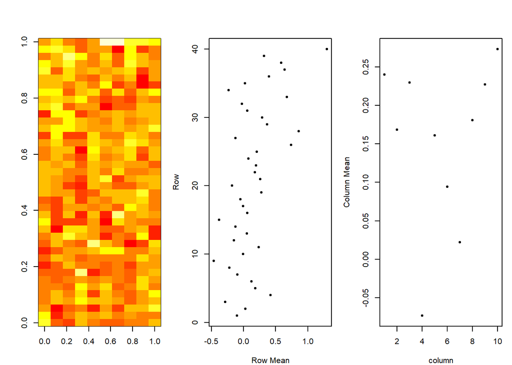

```r
#Patterns in rows and columns
hh <-hclust(dist(dataMatrix))
dataMatrixOrdered <-dataMatrix[hh$order,]
par(mfrow=c(1,3),mar=c(4,4,2,1),oma=c(0,0,2,0))
image(t(dataMatrixOrdered)[,nrow(dataMatrixOrdered):1])
plot(rowMeans(dataMatrixOrdered),40:1,xlab="Row Mean",ylab="Row",pch=20)
plot(colMeans(dataMatrixOrdered),xlab="column",ylab="Column Mean",pch=20)
```

## Dimension Reduction(part2)

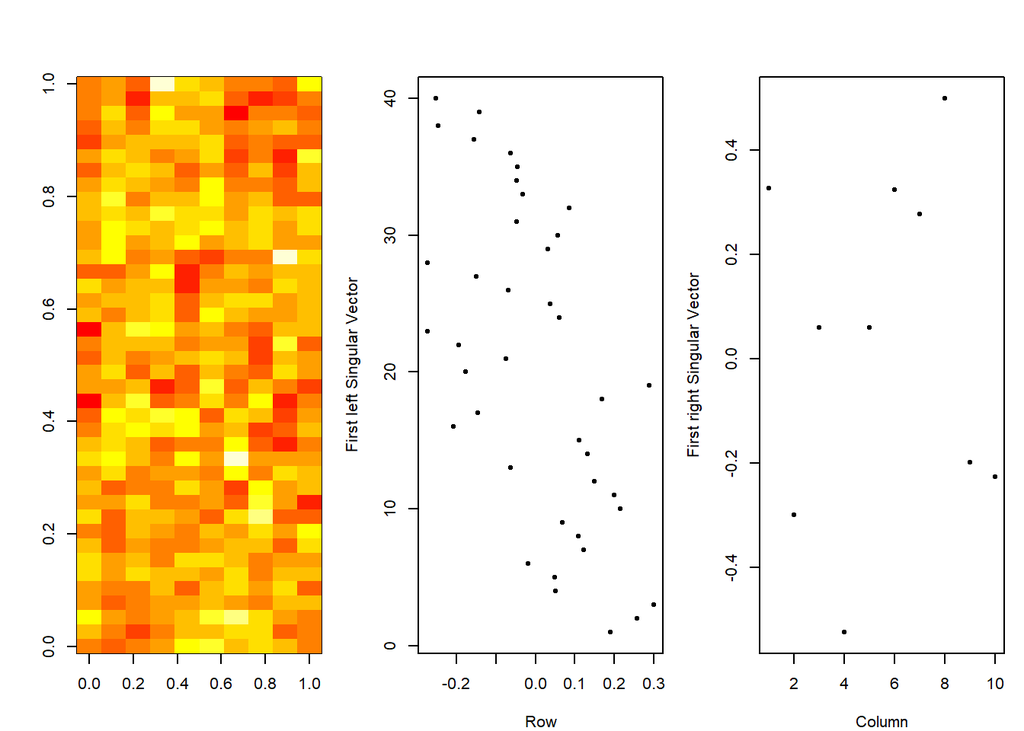

```r
#components of the svd (u and v)
dataMatrix <-matrix(rnorm(400),nrow=40)
hh <-hclust(dist(dataMatrix))
dataMatrixOrdered <-dataMatrix[hh$order,]
svd1 <-svd(scale(dataMatrixOrdered))
par(mfrow=c(1,3),mar=c(4,4,2,1),oma=c(0,0,2,0))
image(t(dataMatrixOrdered)[,nrow(dataMatrixOrdered):1])
plot(svd1$u[,1],40:1,xlab="Row",ylab="First left Singular Vector",pch=20)
plot(svd1$v[,1],xlab="Column",ylab="First right Singular Vector",pch=20)
```

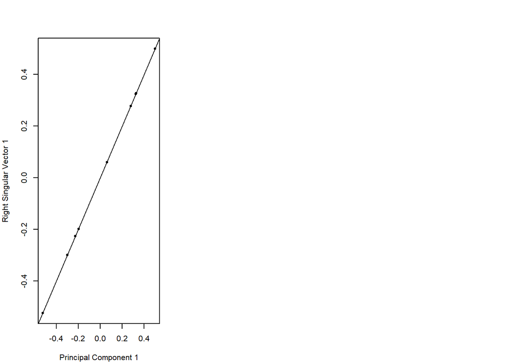

```r
#Relationship to principal components analysis
pca1 <-prcomp(dataMatrixOrdered,scale=TRUE)
plot(pca1$rotation[,1],svd1$v[,1],pch=20,xlab="Principal Component 1",ylab="Right Singular Vector 1")
abline(c(0,1))
#SVD and PCA are essentially the same thing.
```